# Predicting classes of movement activity

# Overview

Using devices to track movement activity of six young health individuals, this project provides an predictive analysis of where each movement falls into 5 different classes: exactly according to the specification (Class A), throwing the elbows to the front (Class B), lifting the dumbbell only halfway (Class C), lowering the dumbbell only halfway (Class D) and throwing the hips to the front (Class E).

The data set from this course came from http://groupware.les.inf.puc-rio.br/har WLE dataset and thank to its contributors Velloso, E.; Bulling, A.; Gellersen, H.; Ugulino, W.; Fuks, H for it’s use.

The training / testing data for this project are available here: https://d396qusza40orc.cloudfront.net/predmachlearn/pml-training.csv https://d396qusza40orc.cloudfront.net/predmachlearn/pml-testing.csv

# How we built the model

We build the model Load in the training and test sets as given. Cross validation was performed on the training by taking 70% of it to build the prediction algorthim. Predication algorithm used was random forest trees because they are best suited for classification problems such as this one.

# Load data and clean and cross validation

```r
library(caret)
#load data into datasets
training <- read.csv(file="pml-training.csv", header=TRUE, sep=",")
testing <- read.csv(file="pml-testing.csv", header=TRUE, sep=",")

#load in data and partition 70% for training
inTrain <- createDataPartition(y=training$classe, p=0.7, list=FALSE)
myTrain <- training[inTrain, ]
myTest <- training[-inTrain, ]

#remove any columns with NA values
myTrainClean <- myTrain[,colSums(is.na(myTrain)) == 0]
myTestClean <-myTest[,colSums(is.na(myTest)) == 0]

#remove the first 7 columns as they are not pertinent to determine classe
myTrainClean <- myTrainClean[, -c(1:7)]
myTestClean <- myTestClean[, -c(1:7)]
```

We test whether or not there are columns that have any variability. If they do not, they have no influence over the predictor and we can throw them out. This equates to any nzv of true.

```r
nsv <- nearZeroVar(myTrainClean)
myTrainClean <- myTrainClean[, -nsv]
```

We fit a random forest model as follows.

```r
set.seed(13243)
modFit <- train(classe~ ., data=myTrainClean, method="rf")
```

# Expected out of sample error

```r
predict <- predict(modFit, myTestClean)
confusionMatrix(myTestClean$classe, predict)
```

```
## Confusion Matrix and Statistics
##
##           Reference
## Prediction    A    B    C    D    E
##          A 1674    0    0    0    0
##          B    7 1129    2    1    0
##          C    0    3 1019    4    0
##          D    0    1    5  957    1
##          E    0    1    0    5 1076
##
## Overall Statistics
##
##                Accuracy : 0.9949
##                  95% CI : (0.9927, 0.9966)
##     No Information Rate : 0.2856
##     P-Value [Acc > NIR] : < 2.2e-16
##
##                   Kappa : 0.9936
##  Mcnemar's Test P-Value : NA
##
## Statistics by Class:
##
##                      Class: A Class: B Class: C Class: D Class: E
## Sensitivity            0.9958   0.9956   0.9932   0.9897   0.9991
## Specificity            1.0000   0.9979   0.9986   0.9986   0.9988
## Pos Pred Value         1.0000   0.9912   0.9932   0.9927   0.9945
## Neg Pred Value         0.9983   0.9989   0.9986   0.9980   0.9998
## Prevalence             0.2856   0.1927   0.1743   0.1643   0.1830
## Detection Rate         0.2845   0.1918   0.1732   0.1626   0.1828
## Detection Prevalence   0.2845   0.1935   0.1743   0.1638   0.1839
## Balanced Accuracy      0.9979   0.9967   0.9959   0.9941   0.9989
```

# Print off 20 test cases using the test data set provided by the WLE dataset.

```r
predict_final <- predict(modFit, testing)
print("The sample length is", length(predict_final))
```

```
## [1] "The sample length is"
```

```r
print(predict_final)
```

```
##  [1] B A B A A E D B A A B C B A E E A B B B
## Levels: A B C D E
```

# Appendix - Diagrams

The following diagrams supplement the research. We find out what the 20 most important variables are and plot the top two against each other. We see a clear deliniation from pitch_forearm and roll_belt and how the classes are quite different from one another - thereby giving a graphical representation of two good predictors.

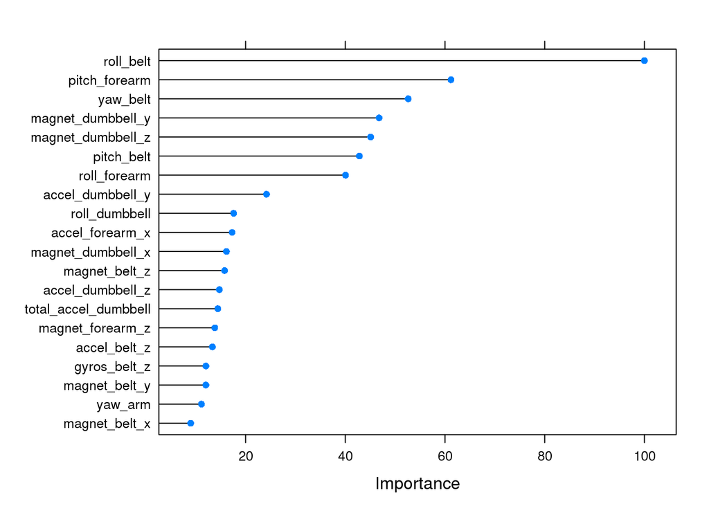

```r
#Diagram #1: Plot 20 most important variables
training_imp <- varImp(modFit)
plot(training_imp, top=20)
```

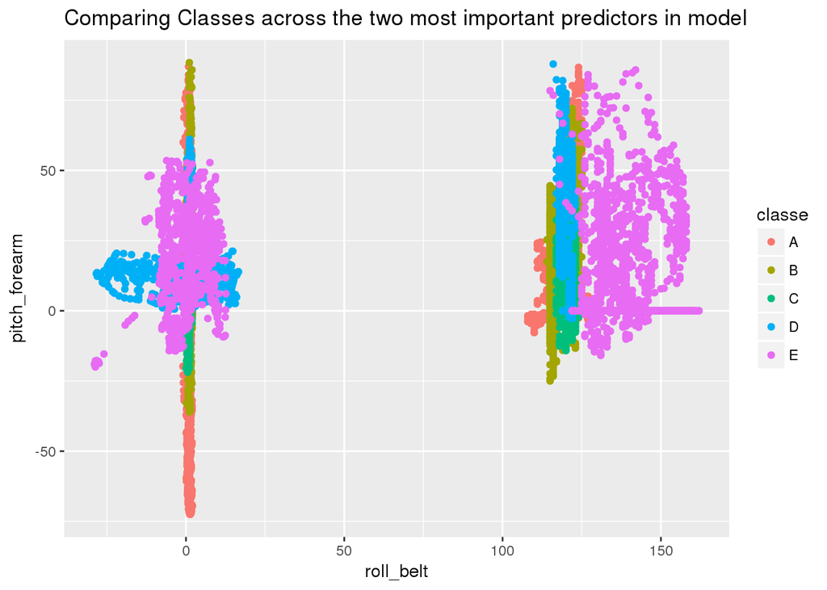

```r
#Diagram #2:  Plot two most important variables
qplot(roll_belt, pitch_forearm,col=classe,data=myTrainClean) + ggtitle("Comparing Classes across the two most important predictors in model")
```